# ABE 516 Assignment: Linear Regression

Weiquan Luo

2019-10-08

### Prerequisites

```r
library(dplyr) # data manipulation
library(stats) # statistical calculations and random number generation.
```

# 1. Introduction

The question of this study is to understand how Birth rate of a country is relative to factors such as:

- Geography: Area,
- People and Society: Population, Median age,
- Economy: Labor force, Inflation rate,
- Communications: number of users within a country that access the Internet,
- Transportaion: number of Airports.

The linear regression model is the primary method for this task. And two additional modeling techque are include just for chanllenge myself:

- Simple linear regression model
- Generalized linear Model
- Generalized Additive Model

# 2. Dataset

The data is obtained by using web scraping on the The World Factbook published by CIA.

```r
library(rvest)
library(tidyverse)
library(furrr)
library(tictoc)
source("ud_function.R")
plan(multiprocess) # switch to parallel computing

# the base url
url <- "https://www.cia.gov/library/publications/resources/the-world-factbook/docs/rankorderguide.html"

# extract href and the relevent text from base url, and form dataframe df
href <- read_html(url) %>% html_nodes(".field_label") %>% html_nodes("strong a") %>% html_attr(name="href")
t <- read_html(url) %>% html_nodes(".field_label") %>% html_nodes("strong a") %>% html_text()
df <- data.frame(t = t, href = href, stringsAsFactors = FALSE) %>%
  mutate_all(as.character())

# map the scrapone() function to each row of dataset df
tic()
table <- furrr::future_map2_dfr(df$href, df$t, function(x,y) scrapOne(x = x, url= url, t= y))
toc()
```

```
## 4.608 sec elapsed
```

```r
plan(sequential) # back to sequential computing
```

```r
# use user-defined function to clear the dataset
table <- table %>% group_by(Country) %>% summarise_all(coalesce_by_column)
table <- table %>% group_by(Country) %>% mutate_if(is.character,cleanText) %>% mutate_all(as.numeric)
colnames(table) <- gsub(":", "", colnames(table))
colnames(table) <- gsub(" ", "", colnames(table))

n_na <- colSums(!is.na(table))
n <- n_na[n_na>225] %>% names
table_subset <- table[colnames(table) %in% n]

table_subset <- table_subset %>%
  ungroup() %>%
  rename(Inflationrate = "Inflationrate(consumerprices)") %>%
  select(-Country) %>%
  select(-Populationgrowthrate, -Deathrate, -Netmigrationrate) %>%
  select(Birthrate,everything())
colnames(table_subset) <- gsub("-", "", colnames(table_subset))
table_subset
```

```
## # A tibble: 261 x 8
##    Birthrate   Area Population Medianage Laborforce Inflationrate
##        <dbl>  <dbl>      <dbl>     <dbl>      <dbl>         <dbl>
##  1      37.5 6.52e5   34940837      19      8478000           5
##  2      NA   1.23e2         NA      NA           NA          NA
##  3      13.2 2.87e4    3057220      33.4    1198000           2
##  4      21.5 2.38e6   41657488      28.3   11820000           5.6
##  5      19   2.24e2      50826      26.1      17850          -0.5
##  6       7.3 4.68e2      85708      44.9      39750          -0.9
##  7      43.7 1.25e6   30355880      15.9   12510000          29.8
##  8      12.4 9.10e1      17422      35.1       6049           1.3
##  9      NA   1.42e7         NA      NA           NA          NA
## 10      15.6 4.43e2      95882      32.2      30000           2.5
## # … with 251 more rows, and 2 more variables: Internetusers <dbl>,
## #   Airports <dbl>
```

# 3. Simple Linear Regression Model

By doing a exhaustive search for all possible combinations including interactions, the best linear model for first order and quadratic order are the following:

- lm(formula = Birthrate ~ Medianage) with adjusted $R^2 = 0.849$
- lm(Birthrate ~ Area + Medianage + Inflationrate + Airports + Area:Medianage + Population:Airports + Medianage:Inflationrate + Medianage:Airports) with adjusted $R^2 = 0.8773$

All estimated slope are statistically significant with alpha of 0.05 as shown in the following outputs. By following the principle of Ockham’s razor, I decide to take the lm(formula = Birthrate ~ Medianage) as the best linear model.

```r
library(leaps)
#model selection
# all except Birthrate to be the expanatory variable
lm_p1 <- regsubsets(Birthrate ~ ., data=table_subset, method='exhaustive', nbest=30, really.big=T) %>% summary()
lm_p2 <- regsubsets(Birthrate ~ .^2, data=table_subset, method='exhaustive', nbest=30, really.big=T) %>% summary()
lm_p3 <- regsubsets(Birthrate ~ .^3, data=table_subset, method='exhaustive', nbest=30, really.big=T) %>% summary()
lm <- list(lm_p1, lm_p2, lm_p3)
```

```r
#Load function of printing
source("Print regsub.R")
#print the best of 5 models
purrr::map(lm, function(x) print.regsub(x, sort='Cp', best=5))
```

```
## [[1]]
##                      model nvar       Rsq    AdjRsq         Cp       AIC
## 1                Medianage    1 0.8524861 0.8517869 -1.3503387 -400.2850
## 8           Area Medianage    2 0.8527082 0.8513055  0.3368886 -398.6061
## 9  Medianage Inflationrate    2 0.8526834 0.8512803  0.3719188 -398.5701
## 10    Population Medianage    2 0.8525725 0.8511685  0.5279164 -398.4100
## 11    Medianage Laborforce    2 0.8525465 0.8511422  0.5645990 -398.3723
##          BIC
## 1  -396.9237
## 8  -391.8835
## 9  -391.8475
## 10 -391.6874
## 11 -391.6497
##
## [[2]]
```

[output cut: 26 more lines]

```r
#specify the variables
lm_p1_best <- lm(Birthrate ~ Medianage,
                             data = table_subset)
summary(lm_p1_best)
```

```
##
## Call:
## lm(formula = Birthrate ~ Medianage, data = table_subset)
##
## Residuals:
##     Min      1Q  Median      3Q     Max
## -7.5171 -2.7106 -0.4801  2.3685 10.4055
##
## Coefficients:
##             Estimate Std. Error t value Pr(>|t|)
## (Intercept) 48.57227    0.87138   55.74   <2e-16 ***
## Medianage   -0.96087    0.02706  -35.51   <2e-16 ***
## ---
## Signif. codes:  0 '***' 0.001 '**' 0.01 '*' 0.05 '.' 0.1 ' ' 1
##
## Residual standard error: 3.633 on 223 degrees of freedom
##   (36 observations deleted due to missingness)
## Multiple R-squared:  0.8497, Adjusted R-squared:  0.849
## F-statistic:  1261 on 1 and 223 DF,  p-value: < 2.2e-16
```

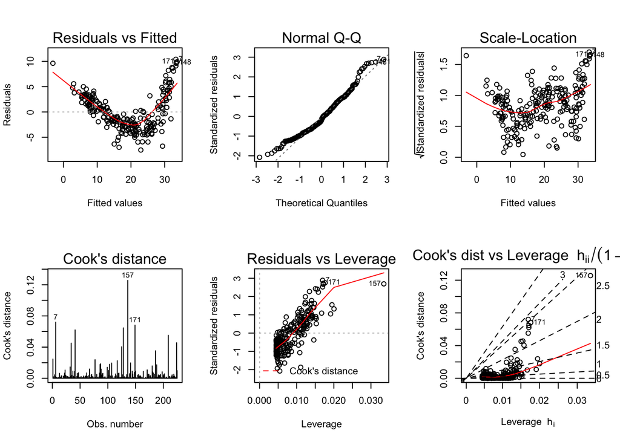

```r
par(mfrow= c(2,3))
plot(lm_p1_best, which=1:6)
```

# 5. Alternative Model

## 5.1 Generalized linear Model

As a U shape shown in the residual plot from the one variable linear model, I suggest to use a generalized linear Model using a inverse linkage function of Gamma family.

```r
glm_p1 <- glm(Birthrate ~ Medianage, family = Gamma(),
              data = table_subset)
summary(glm_p1)
```

```
##
## Call:
## glm(formula = Birthrate ~ Medianage, family = Gamma(), data = table_subset)
##
## Deviance Residuals:
##      Min        1Q    Median        3Q       Max
## -0.38367  -0.06327   0.00433   0.06706   0.25969
##
## Coefficients:
##               Estimate Std. Error t value Pr(>|t|)
## (Intercept) -2.446e-02  1.081e-03  -22.64   <2e-16 ***
## Medianage    2.887e-03  4.445e-05   64.95   <2e-16 ***
## ---
## Signif. codes:  0 '***' 0.001 '**' 0.01 '*' 0.05 '.' 0.1 ' ' 1
##
## (Dispersion parameter for Gamma family taken to be 0.01066702)
##
##     Null deviance: 51.0650  on 224  degrees of freedom
## Residual deviance:  2.4823  on 223  degrees of freedom
##   (36 observations deleted due to missingness)
## AIC: 901.28
##
## Number of Fisher Scoring iterations: 4
```

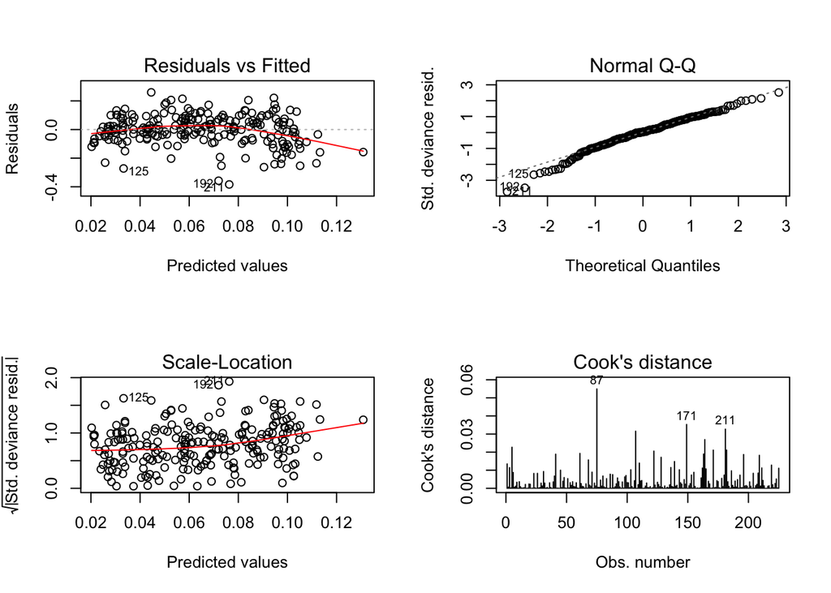

```r
par(mfrow= c(2,2))
plot(glm_p1, which=1:4)
```

## 5.2 Generalized Additive Model

Alternative, I suggest a Generalized Additive Model model could better fit this data.

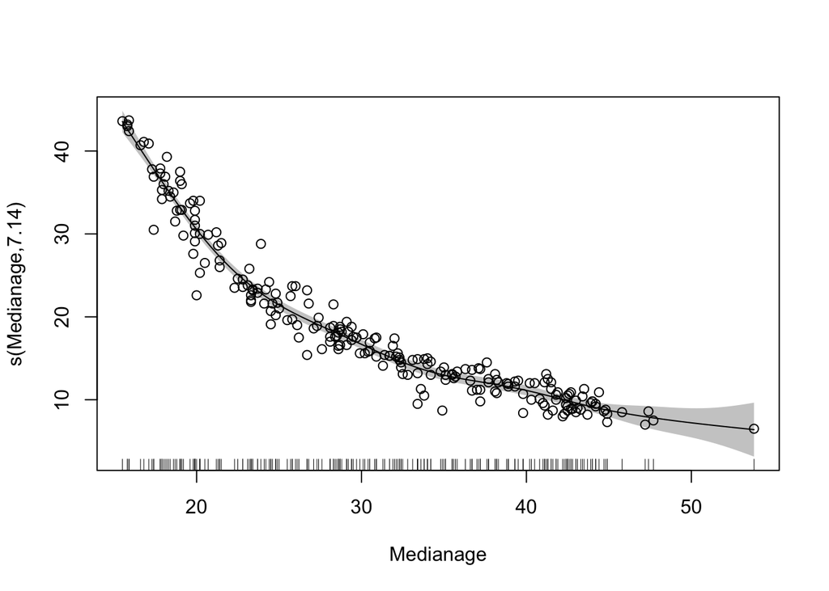

```r
library(mgcv)
gam_p1 <- gam(Birthrate ~ s(Medianage),
              data = table_subset, method = "REML", select = TRUE)
plot(gam_p1, shift = coef(gam_p1)[1],
     seWithMean = TRUE, residuals = TRUE,
     se = TRUE, shade = TRUE,
     rug = TRUE, pch = 1)
```

```r
summary(gam_p1)
```

```
##
## Family: gaussian
## Link function: identity
##
## Formula:
## Birthrate ~ s(Medianage)
##
## Parametric coefficients:
##             Estimate Std. Error t value Pr(>|t|)
## (Intercept)  18.8516     0.1171     161   <2e-16 ***
## ---
## Signif. codes:  0 '***' 0.001 '**' 0.01 '*' 0.05 '.' 0.1 ' ' 1
##
## Approximate significance of smooth terms:
##                edf Ref.df     F p-value
## s(Medianage) 7.143      9 680.6  <2e-16 ***
## ---
## Signif. codes:  0 '***' 0.001 '**' 0.01 '*' 0.05 '.' 0.1 ' ' 1
##
## R-sq.(adj) =  0.965   Deviance explained = 96.6%
## -REML = 461.12  Scale est. = 3.0848    n = 225
```

- The smooth function of variable `Birthrate` are made up of nine basis functions shown by `coef(glm_p1)`.

```r
coef(gam_p1)
```

```
##    (Intercept) s(Medianage).1 s(Medianage).2 s(Medianage).3 s(Medianage).4
##     18.8515556     -2.5436197      9.0063538     -0.1447708      5.3436561
## s(Medianage).5 s(Medianage).6 s(Medianage).7 s(Medianage).8 s(Medianage).9
##      1.4322359     -3.6147858     -1.4613526    -21.5384290    -14.5455180
```

- The `p-value` of basis dimenstion for Medianage indicate that residuals are randomly distributed

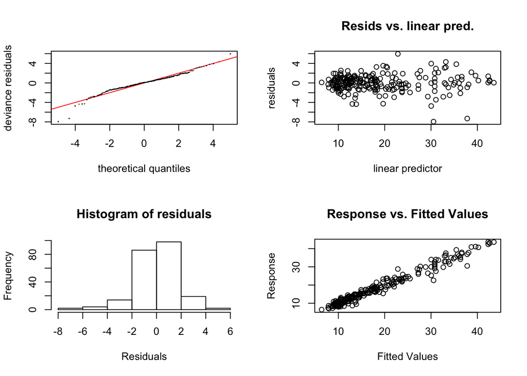

```
##
## Method: REML   Optimizer: outer newton
## full convergence after 13 iterations.
## Gradient range [-3.286027e-05,3.117332e-05]
## (score 461.1156 & scale 3.084839).
## Hessian positive definite, eigenvalue range [0.4806318,112.0892].
## Model rank =  10 / 10
##
## Basis dimension (k) checking results. Low p-value (k-index<1) may
## indicate that k is too low, especially if edf is close to k'.
##
##                k'  edf k-index p-value
## s(Medianage) 9.00 7.14    0.97    0.29
```

```r
par(mfrow= c(2,2))
gam.check(gam_p1)
```

# 5.3 Comparison between alternative models

The generalized linear model have lower value in AIC and BIC, so it is a better model.

```r
AIC(glm_p1); AIC(gam_p1)
```

```
## [1] 901.2842
```

```
## [1] 902.4169
```

```r
BIC(glm_p1); BIC(gam_p1)
```

```
## [1] 911.5325
```

```
## [1] 934.4012
```

# 5. Conclusion

Within the scope of the requirement, I conclude the best linear regresssion model for this dataset is the model with only one variabl Medianage:

$BirthRate_{pred} = 48.572 - 0.96087 \times Median Age, R^2 = 0.852$

The `p-value` for intercept and slope are signficant. It shows that the the estimated value for the coefficient is not equal to zero 0.

However, the assumption of linearity is violated as shown in the residual plot. Some outlier also affect the fit of the model.

# A. Reference: User-defined Function

```r
# user-defined function to scrap table from one href
scrapOne <- function(x, url, t){
  url_abs<-url_absolute(x,base=url)
  table <- read_html(url_abs) %>% html_table
  table <- table[[1]][,2:3] %>% as_tibble() %>% setNames(nm= c("Country",t))
  return(table)
}

# user-defined function to clean the text
cleanText <- function(x){
  x <- gsub("[[:blank:]]", "", x)
  x <- as.numeric(gsub(",","",x))
  x <-  gsub("\n", "", x) # clean up the links names
  return(x)
}

# user-defined function to coalesce the table
coalesce_by_column <- function(df) {
  return(dplyr::coalesce(!!! as.list(df)))
}
```